# practicum

**2012 binge drinking disease data**

```r
# getting binge drinking data 2012
targ_binge2 <- filter(targ_b, Year == "2012", Response == "Yes", Topic == "Binge Drinking")
View(targ_binge2)
```

**getting the top 5 states with binge drinking 2012**

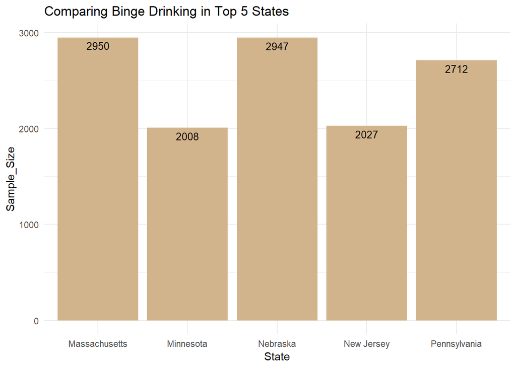

```r
# top 5 states with binge drinking 2012
top_n(targ_binge2, n=5, Sample_Size) %>%
  ggplot(., aes(x=Locationdesc, y=Sample_Size))+ labs(title = "Comparing Binge Drinking in Top 5 States", x = "State") +
  geom_bar(stat = 'identity', fill = "tan")+ geom_text(aes(label=Sample_Size), vjust=1.5, color="black", size = 3.5)+ theme_minimal()
```

**getting bottom 5 states binge drinking 2012**

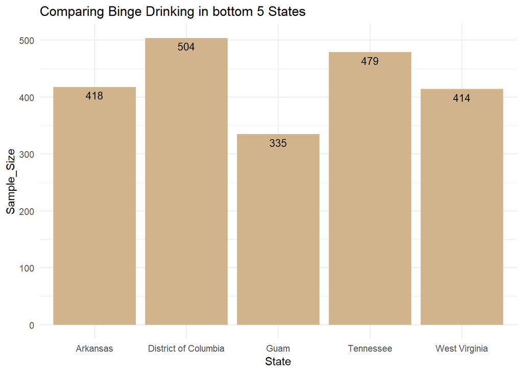

```r
# plotting the bottom 5 states with binge drinking for 2012
top_n(targ_binge2, n=-5, Sample_Size) %>%
  ggplot(., aes(x=Locationdesc, y=Sample_Size))+ labs(title = "Comparing Binge Drinking in bottom 5 States", x = "State") +
  geom_bar(stat = 'identity', fill = "tan")+ geom_text(aes(label=Sample_Size), vjust=1.5, color="black", size = 3.5)+ theme_minimal()
```

In 2012 Massachusetts had the highest cases of binge drinking while Guam recorded the lowest number.

**2013 binge drinking disease data**

```r
# getting binge drinking data 2013
targ_binge3 <- filter(targ_b, Year == "2013", Response == "Yes", Topic == "Binge Drinking")
View(targ_binge3)
```

**getting the top 5 states with binge drinking 2013**

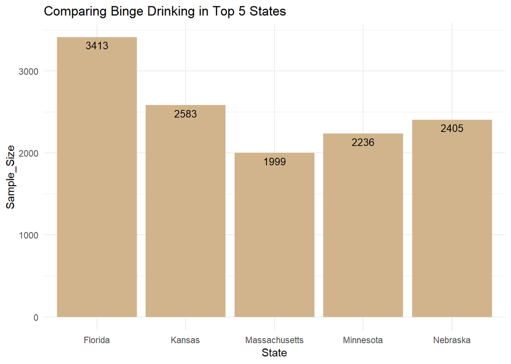

```r
# top 5 states with binge drinking 2013
top_n(targ_binge3, n=5, Sample_Size) %>%
  ggplot(., aes(x=Locationdesc, y=Sample_Size))+ labs(title = "Comparing Binge Drinking in Top 5 States", x = "State") +
  geom_bar(stat = 'identity', fill = "tan")+ geom_text(aes(label=Sample_Size), vjust=1.5, color="black", size = 3.5)+ theme_minimal()
```

**getting bottom 5 states binge drinking 2013**

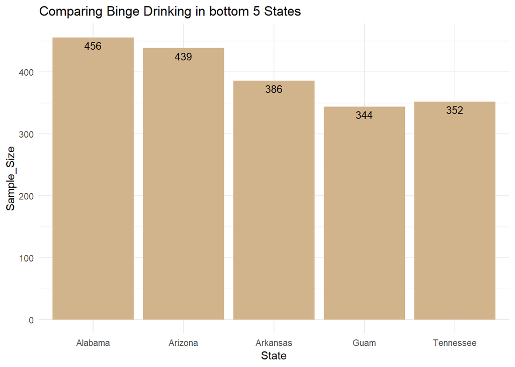

```r
# plotting the bottom 5 states with binge drinking for 2013
top_n(targ_binge3, n=-5, Sample_Size) %>%
  ggplot(., aes(x=Locationdesc, y=Sample_Size))+ labs(title = "Comparing Binge Drinking in bottom 5 States", x = "State") +
  geom_bar(stat = 'identity', fill = "tan")+ geom_text(aes(label=Sample_Size), vjust=1.5, color="black", size = 3.5)+ theme_minimal()
```

In 2013, Floring led the binge drinking category while Guam was last.

**2014 binge drinking disease data**

```r
# getting binge drinking data 2014
targ_binge4 <- filter(targ_b, Year == "2014", Response == "Yes", Topic == "Binge Drinking")
View(targ_binge4)
```

**getting the top 5 states with binge drinking 2014**

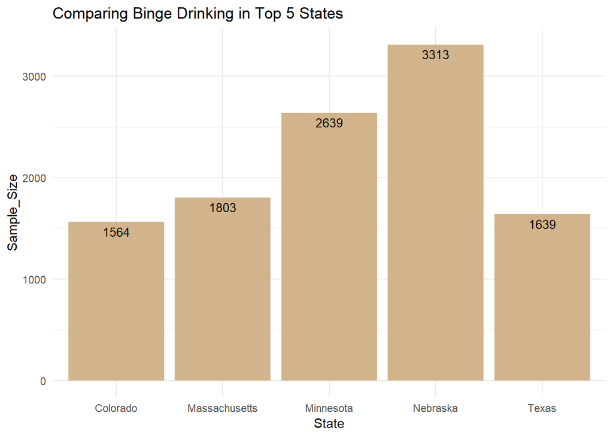

```r
# top 5 states with binge drinking 2014
top_n(targ_binge4, n=5, Sample_Size) %>%
  ggplot(., aes(x=Locationdesc, y=Sample_Size))+ labs(title = "Comparing Binge Drinking in Top 5 States", x = "State") +
  geom_bar(stat = 'identity', fill = "tan")+ geom_text(aes(label=Sample_Size), vjust=1.5, color="black", size = 3.5)+ theme_minimal()
```

**getting bottom 5 states binge drinking 2014**

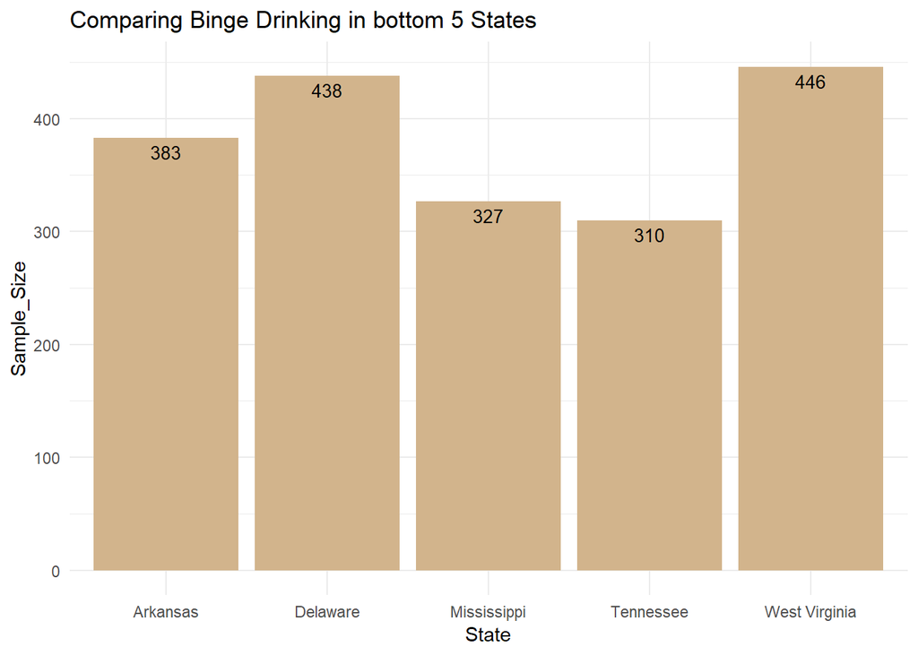

```r
# plotting the bottom 5 states with binge drinking for 2014
top_n(targ_binge4, n=-5, Sample_Size) %>%
  ggplot(., aes(x=Locationdesc, y=Sample_Size))+ labs(title = "Comparing Binge Drinking in bottom 5 States", x = "State") +
  geom_bar(stat = 'identity', fill = "tan")+ geom_text(aes(label=Sample_Size), vjust=1.5, color="black", size = 3.5)+ theme_minimal()
```

In 2014, Nebraska led the chart in Binge drinking while Tennesee was last. **2015 binge drinking disease data**

```r
# getting binge drinking data 2015
targ_binge5 <- filter(targ_b, Year == "2015", Response == "Yes", Topic == "Binge Drinking")
View(targ_binge5)
```

**getting the top 5 states with binge drinking 2015**

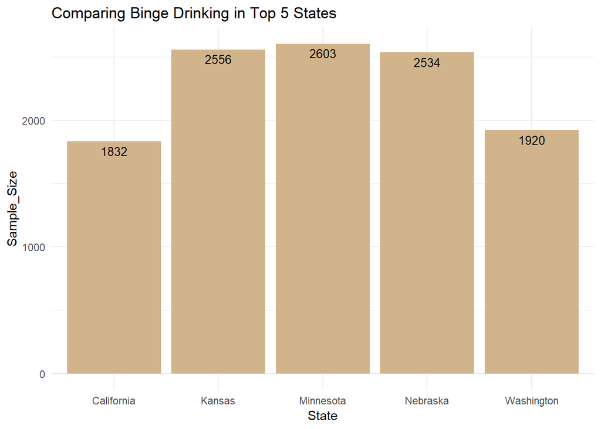

```r
# top 5 states with binge drinking 2015
top_n(targ_binge5, n=5, Sample_Size) %>%
  ggplot(., aes(x=Locationdesc, y=Sample_Size))+ labs(title = "Comparing Binge Drinking in Top 5 States", x = "State") +
  geom_bar(stat = 'identity', fill = "tan")+ geom_text(aes(label=Sample_Size), vjust=1.5, color="black", size = 3.5)+ theme_minimal()
```

**getting bottom 5 states binge drinking 2015**

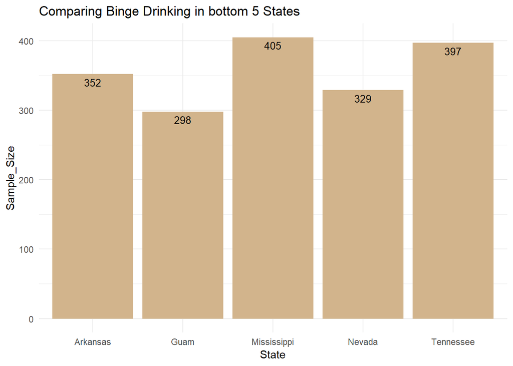

```r
# plotting the bottom 5 states with binge drinking for 2015
top_n(targ_binge5, n=-5, Sample_Size) %>%
  ggplot(., aes(x=Locationdesc, y=Sample_Size))+ labs(title = "Comparing Binge Drinking in bottom 5 States", x = "State") +
  geom_bar(stat = 'identity', fill = "tan")+ geom_text(aes(label=Sample_Size), vjust=1.5, color="black", size = 3.5)+ theme_minimal()
```

In 2015 Minnesota was the highest in binge drinking while Guam was last.

**2016 binge drinking disease data**

```r
# getting binge drinking data 2016
targ_binge6 <- filter(targ_b, Year == "2016", Response == "Yes", Topic == "Binge Drinking")
View(targ_binge6)
```

**getting the top 5 states with binge drinking 2016**

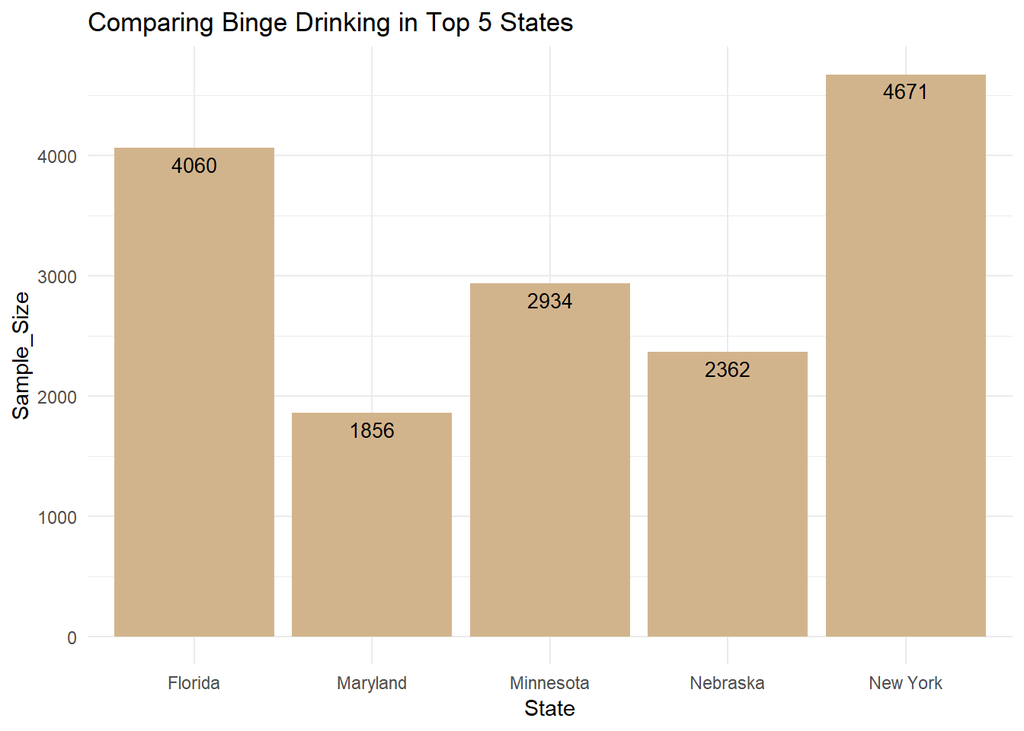

```r
# top 5 states with binge drinking 2016
top_n(targ_binge6, n=5, Sample_Size) %>%
  ggplot(., aes(x=Locationdesc, y=Sample_Size))+ labs(title = "Comparing Binge Drinking in Top 5 States", x = "State") +
  geom_bar(stat = 'identity', fill = "tan")+ geom_text(aes(label=Sample_Size), vjust=1.5, color="black", size = 3.5)+ theme_minimal()
```

**getting bottom 5 states binge drinking 2016**

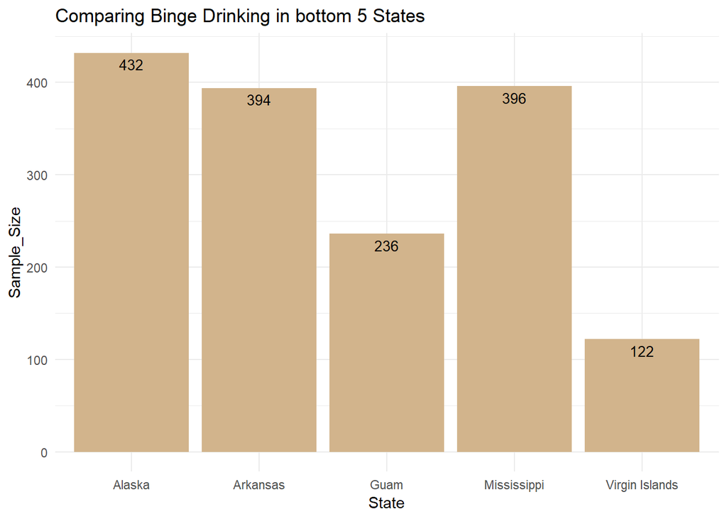

```r
# plotting the bottom 5 states with binge drinking for 2016
top_n(targ_binge6, n=-5, Sample_Size) %>%
  ggplot(., aes(x=Locationdesc, y=Sample_Size))+ labs(title = "Comparing Binge Drinking in bottom 5 States", x = "State") +
  geom_bar(stat = 'identity', fill = "tan")+ geom_text(aes(label=Sample_Size), vjust=1.5, color="black", size = 3.5)+ theme_minimal()
```

In 2016 New York had the highest number of binge drinkers while virgin Island had the least.

**2017 binge drinking disease data**

```r
# getting binge drinking data 2017
targ_binge7 <- filter(targ_b, Year == "2017", Response == "Yes", Topic == "Binge Drinking")
View(targ_binge7)
```

**getting the top 5 states with binge drinking 2017**

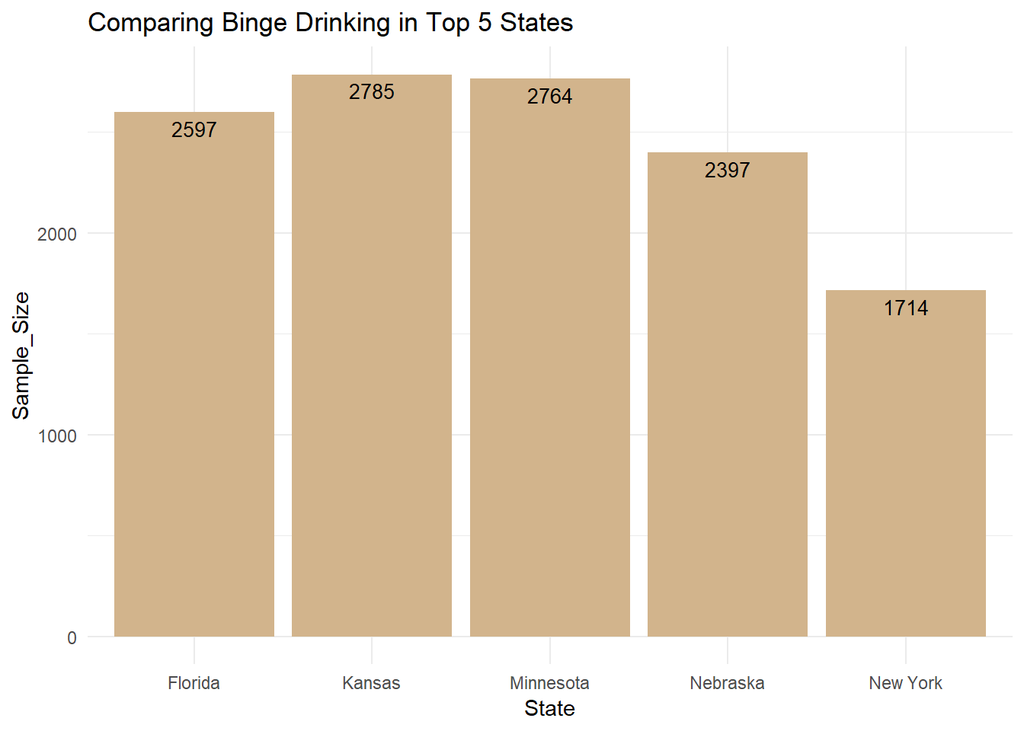

```r
# top 5 states with binge drinking 2017
top_n(targ_binge7, n=5, Sample_Size) %>%
  ggplot(., aes(x=Locationdesc, y=Sample_Size))+ labs(title = "Comparing Binge Drinking in Top 5 States", x = "State") +
  geom_bar(stat = 'identity', fill = "tan")+ geom_text(aes(label=Sample_Size), vjust=1.5, color="black", size = 3.5)+ theme_minimal()
```

**getting bottom 5 states binge drinking 2017**

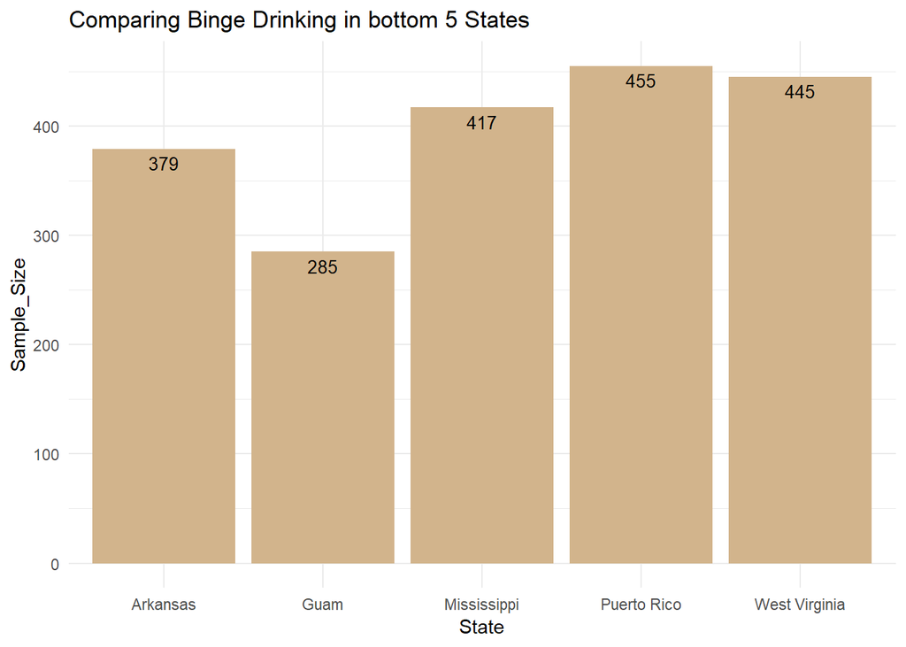

```r
# plotting the bottom 5 states with binge drinking for 2017
top_n(targ_binge7, n=-5, Sample_Size) %>%
  ggplot(., aes(x=Locationdesc, y=Sample_Size))+ labs(title = "Comparing Binge Drinking in bottom 5 States", x = "State") +
  geom_bar(stat = 'identity', fill = "tan")+ geom_text(aes(label=Sample_Size), vjust=1.5, color="black", size = 3.5)+ theme_minimal()
```

In 2017 Kansas was leading and was followed by Guam.

The forth condition am covering is depression. Depression is a serious mental condition, and I chose to cover to see if geographical location could impact depression. My approach is still the same covering the top 5 and bottom 5 states in depression.

**2011 depression data**

```r
# getting binge drinking data 2011
targ_dep <- filter(targ_b, Year == "2011", Response == "Yes", Topic == "Depression")
View(targ_dep)
```

**getting the top 5 states with depression 2011**

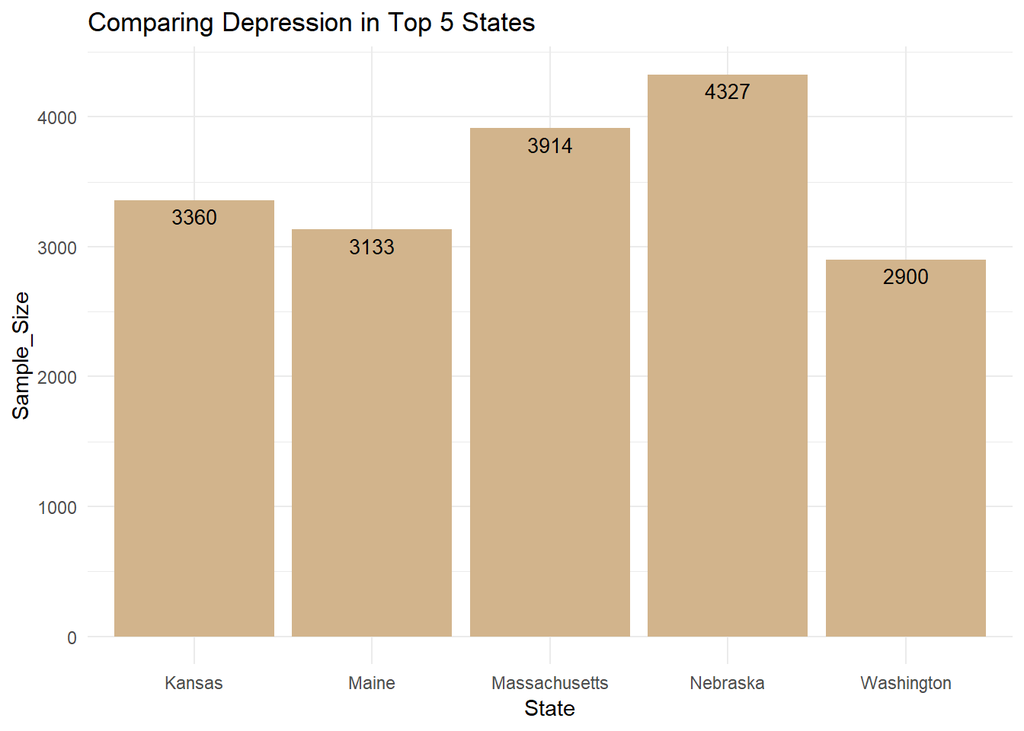

```r
# top 5 states with binge drinking 2011
top_n(targ_dep, n=5, Sample_Size) %>%
  ggplot(., aes(x=Locationdesc, y=Sample_Size))+ labs(title = "Comparing Depression in Top 5 States", x = "State") +
  geom_bar(stat = 'identity', fill = "tan")+ geom_text(aes(label=Sample_Size), vjust=1.5, color="black", size = 3.5)+ theme_minimal()
```

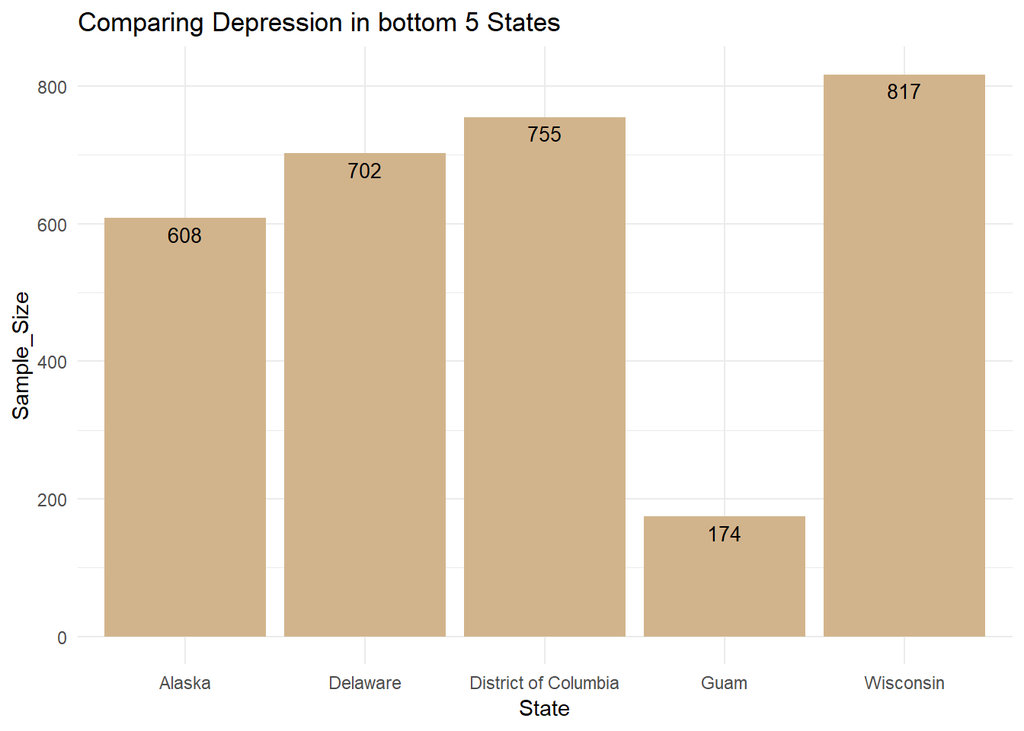

```r
# plotting the bottom 5 states with binge drinking for 2011
top_n(targ_dep, n=-5, Sample_Size) %>%
  ggplot(., aes(x=Locationdesc, y=Sample_Size))+ labs(title = "Comparing Depression in bottom 5 States", x = "State") +
  geom_bar(stat = 'identity', fill = "tan")+ geom_text(aes(label=Sample_Size), vjust=1.5, color="black", size = 3.5)+ theme_minimal()
```

In 2011, Nebraska had the highest number of depression patients while GUam had the least.

**2012 depression data**

```r
# getting binge drinking data 2012
targ_dep2 <- filter(targ_b, Year == "2012", Response == "Yes", Topic == "Depression")
View(targ_dep2)
```

**getting the top 5 states with depression 2012**

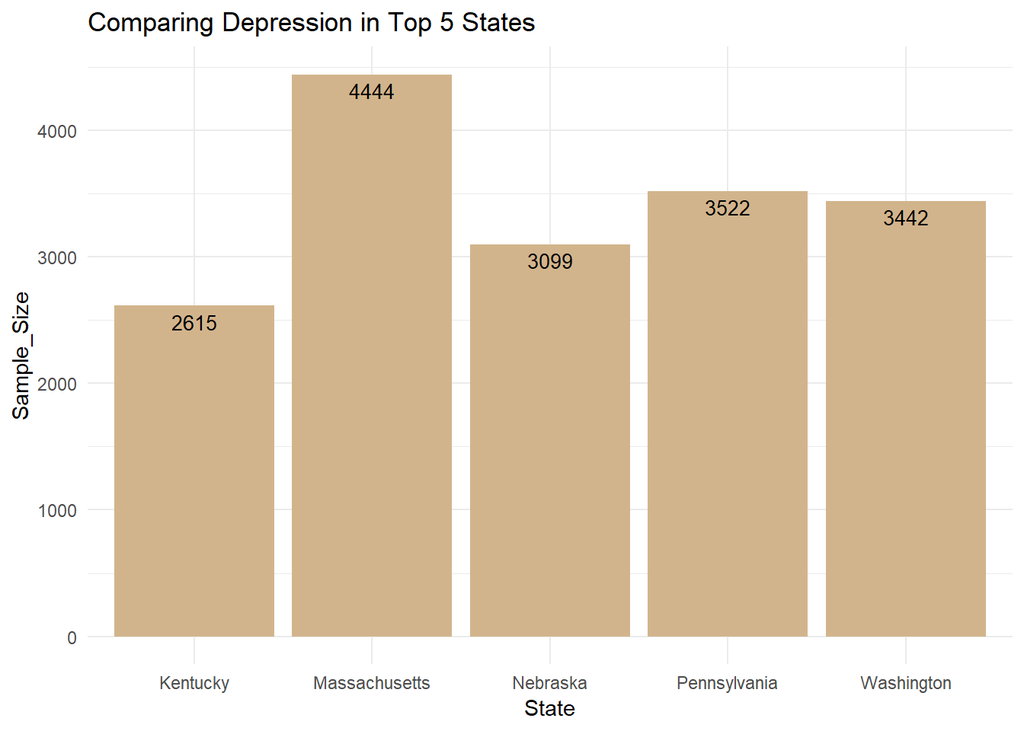

```r
# top 5 states with binge drinking 2012
top_n(targ_dep2, n=5, Sample_Size) %>%
  ggplot(., aes(x=Locationdesc, y=Sample_Size))+ labs(title = "Comparing Depression in Top 5 States", x = "State") +
  geom_bar(stat = 'identity', fill = "tan")+ geom_text(aes(label=Sample_Size), vjust=1.5, color="black", size = 3.5)+ theme_minimal()
```

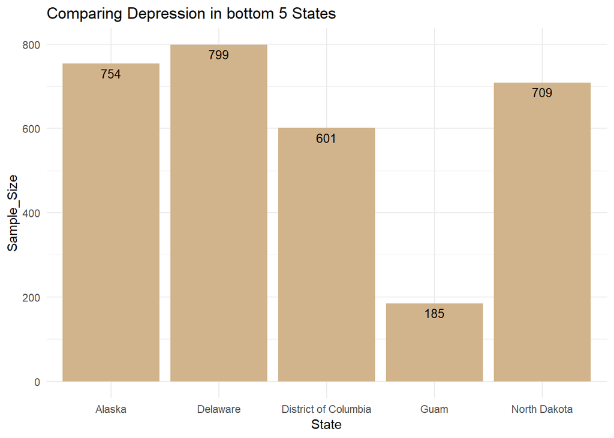

```r
# plotting the bottom 5 states with binge drinking for 2012
top_n(targ_dep2, n=-5, Sample_Size) %>%
  ggplot(., aes(x=Locationdesc, y=Sample_Size))+ labs(title = "Comparing Depression in bottom 5 States", x = "State") +
  geom_bar(stat = 'identity', fill = "tan")+ geom_text(aes(label=Sample_Size), vjust=1.5, color="black", size = 3.5)+ theme_minimal()
```

In 2012 Massachusetts had the highest number while Guam had the least.

**2013 depression data**

```r
# getting binge drinking data 2013
targ_dep3 <- filter(targ_b, Year == "2013", Response == "Yes", Topic == "Depression")
View(targ_dep3)
```

**getting the top 5 states with depression 2013**

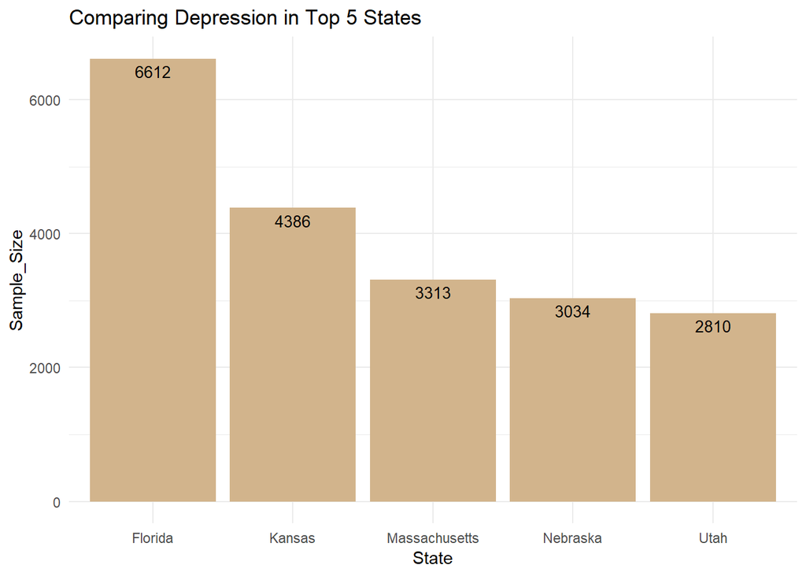

```r
# top 5 states with binge drinking 2013
top_n(targ_dep3, n=5, Sample_Size) %>%
  ggplot(., aes(x=Locationdesc, y=Sample_Size))+ labs(title = "Comparing Depression in Top 5 States", x = "State") +
  geom_bar(stat = 'identity', fill = "tan")+ geom_text(aes(label=Sample_Size), vjust=1.5, color="black", size = 3.5)+ theme_minimal()
```

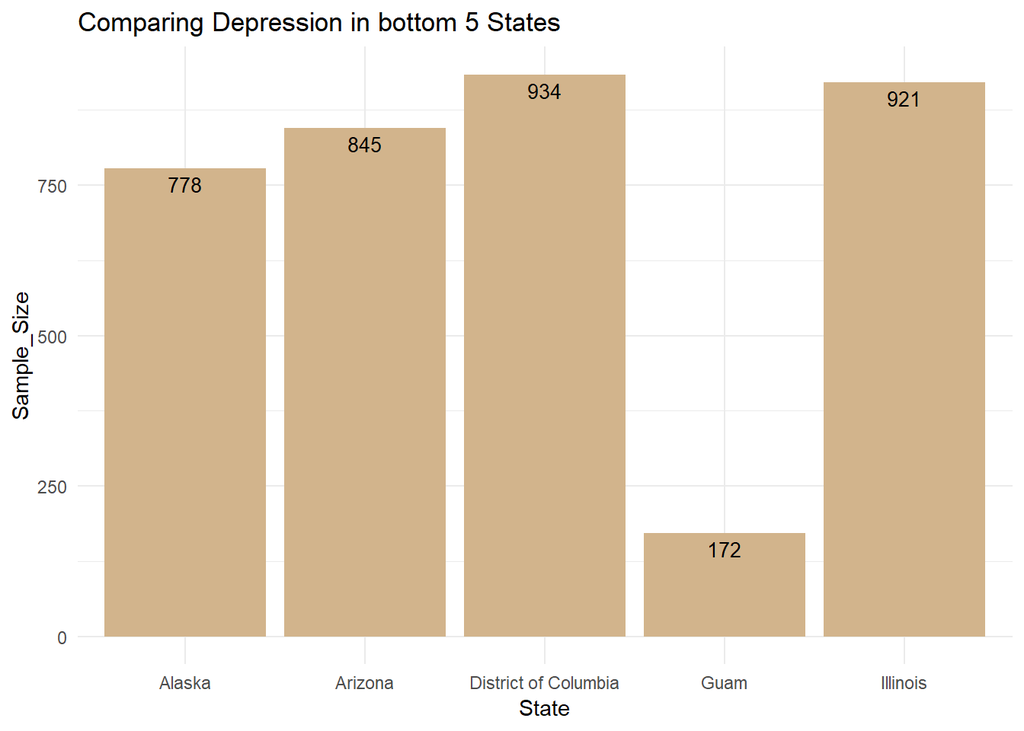

```r
# plotting the bottom 5 states with binge drinking for 2013
top_n(targ_dep3, n=-5, Sample_Size) %>%
  ggplot(., aes(x=Locationdesc, y=Sample_Size))+ labs(title = "Comparing Depression in bottom 5 States", x = "State") +
  geom_bar(stat = 'identity', fill = "tan")+ geom_text(aes(label=Sample_Size), vjust=1.5, color="black", size = 3.5)+ theme_minimal()
```

in 2013 Florida had the highest cases of depression while Guam had the least.

**2014 depression data**

```r
# getting binge drinking data 2014
targ_dep4 <- filter(targ_b, Year == "2014", Response == "Yes", Topic == "Depression")
View(targ_dep4)
```

**getting the top 5 states with depression 2014**

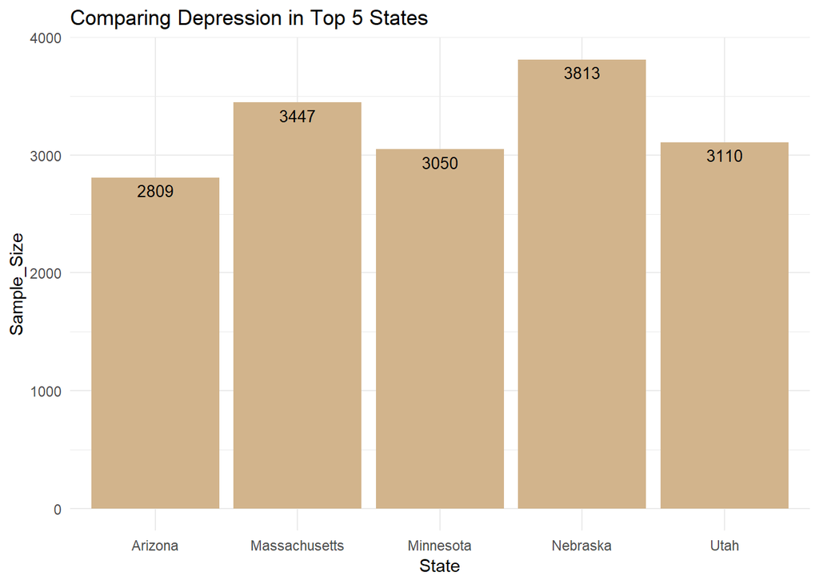

```r
# top 5 states with binge drinking 2014
top_n(targ_dep4, n=5, Sample_Size) %>%
  ggplot(., aes(x=Locationdesc, y=Sample_Size))+ labs(title = "Comparing Depression in Top 5 States", x = "State") +
  geom_bar(stat = 'identity', fill = "tan")+ geom_text(aes(label=Sample_Size), vjust=1.5, color="black", size = 3.5)+ theme_minimal()
```

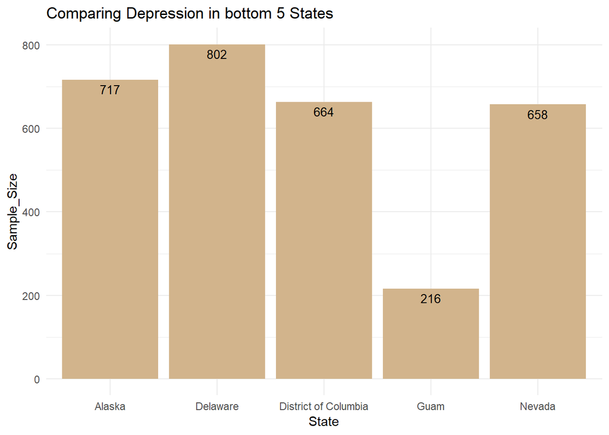

```r
# plotting the bottom 5 states with binge drinking for 2014
top_n(targ_dep4, n=-5, Sample_Size) %>%
  ggplot(., aes(x=Locationdesc, y=Sample_Size))+ labs(title = "Comparing Depression in bottom 5 States", x = "State") +
  geom_bar(stat = 'identity', fill = "tan")+ geom_text(aes(label=Sample_Size), vjust=1.5, color="black", size = 3.5)+ theme_minimal()
```

In 2014 nebraska was leadin and last was Guam.

**2015 depression data**

```r
# getting binge drinking data 2015
targ_dep5 <- filter(targ_b, Year == "2015", Response == "Yes", Topic == "Depression")
View(targ_dep5)
```

**getting the top 5 states with depression 2015**

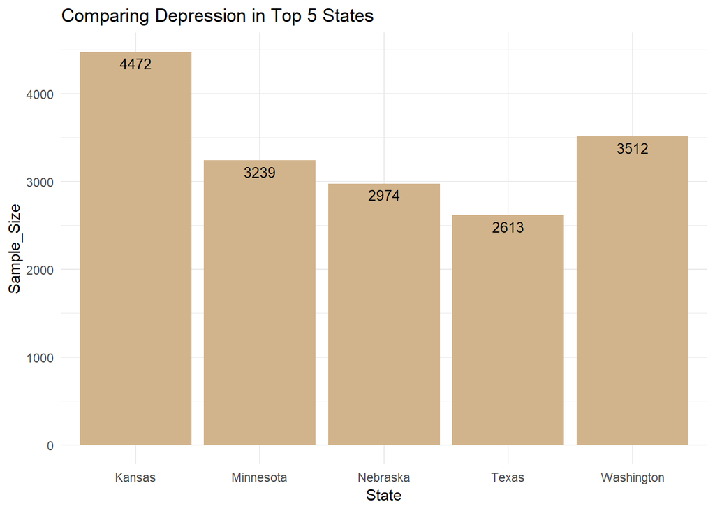

```r
# top 5 states with binge drinking 2015
top_n(targ_dep5, n=5, Sample_Size) %>%
  ggplot(., aes(x=Locationdesc, y=Sample_Size))+ labs(title = "Comparing Depression in Top 5 States", x = "State") +
  geom_bar(stat = 'identity', fill = "tan")+ geom_text(aes(label=Sample_Size), vjust=1.5, color="black", size = 3.5)+ theme_minimal()
```

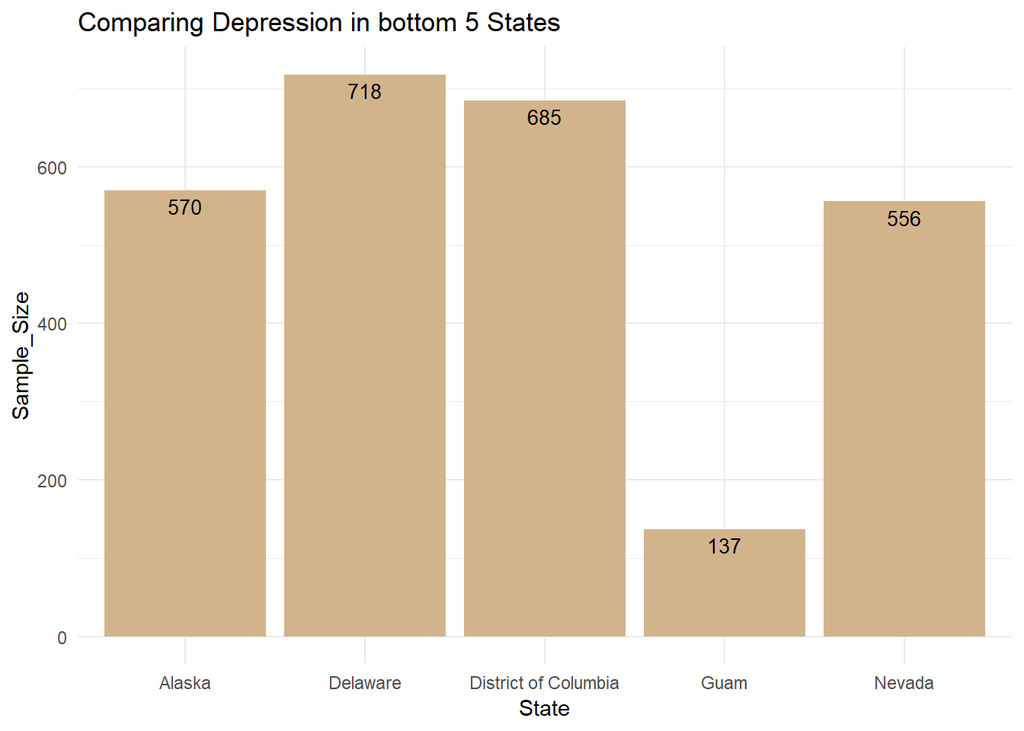

```r
# plotting the bottom 5 states with binge drinking for 2015
top_n(targ_dep5, n=-5, Sample_Size) %>%
  ggplot(., aes(x=Locationdesc, y=Sample_Size))+ labs(title = "Comparing Depression in bottom 5 States", x = "State") +
  geom_bar(stat = 'identity', fill = "tan")+ geom_text(aes(label=Sample_Size), vjust=1.5, color="black", size = 3.5)+ theme_minimal()
```

In 2015 Kansas had the highest cases of depression while GUam had the least.

**2016 depression data**

```r
# getting binge drinking data 2016
targ_dep6 <- filter(targ_b, Year == "2016", Response == "Yes", Topic == "Depression")
View(targ_dep6)
```

**getting the top 5 states with depression 2016**

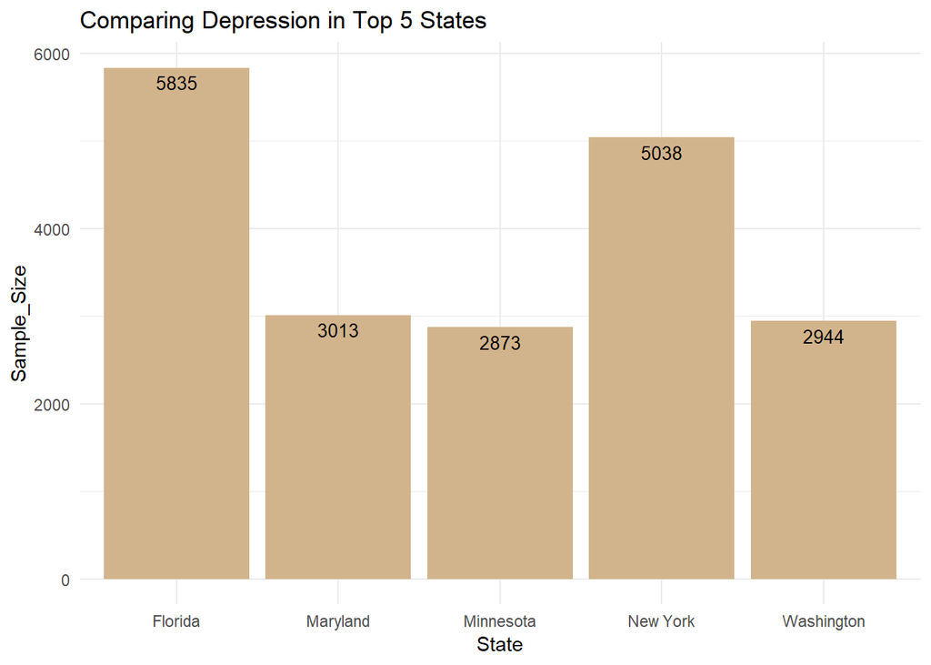

```r
# top 5 states with binge drinking 2016
top_n(targ_dep6, n=5, Sample_Size) %>%
  ggplot(., aes(x=Locationdesc, y=Sample_Size))+ labs(title = "Comparing Depression in Top 5 States", x = "State") +
  geom_bar(stat = 'identity', fill = "tan")+ geom_text(aes(label=Sample_Size), vjust=1.5, color="black", size = 3.5)+ theme_minimal()
```

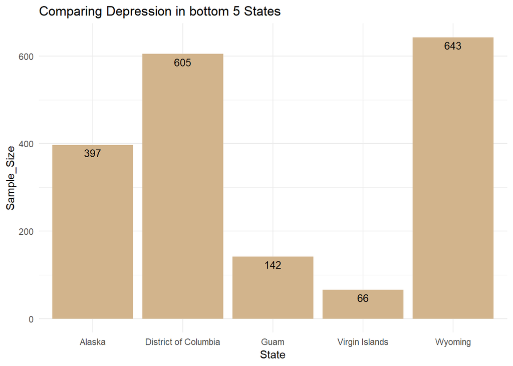

```r
# plotting the bottom 5 states with binge drinking for 2016
top_n(targ_dep6, n=-5, Sample_Size) %>%
  ggplot(., aes(x=Locationdesc, y=Sample_Size))+ labs(title = "Comparing Depression in bottom 5 States", x = "State") +
  geom_bar(stat = 'identity', fill = "tan")+ geom_text(aes(label=Sample_Size), vjust=1.5, color="black", size = 3.5)+ theme_minimal()
```

In 2016 Florida had the most cases of depression while Virgin Island had the least cases of depression.

**2017 depression data**

```r
# getting binge drinking data 2017
targ_dep7 <- filter(targ_b, Year == "2017", Response == "Yes", Topic == "Depression")
View(targ_dep7)
```

**getting the top 5 states with depression 2017**

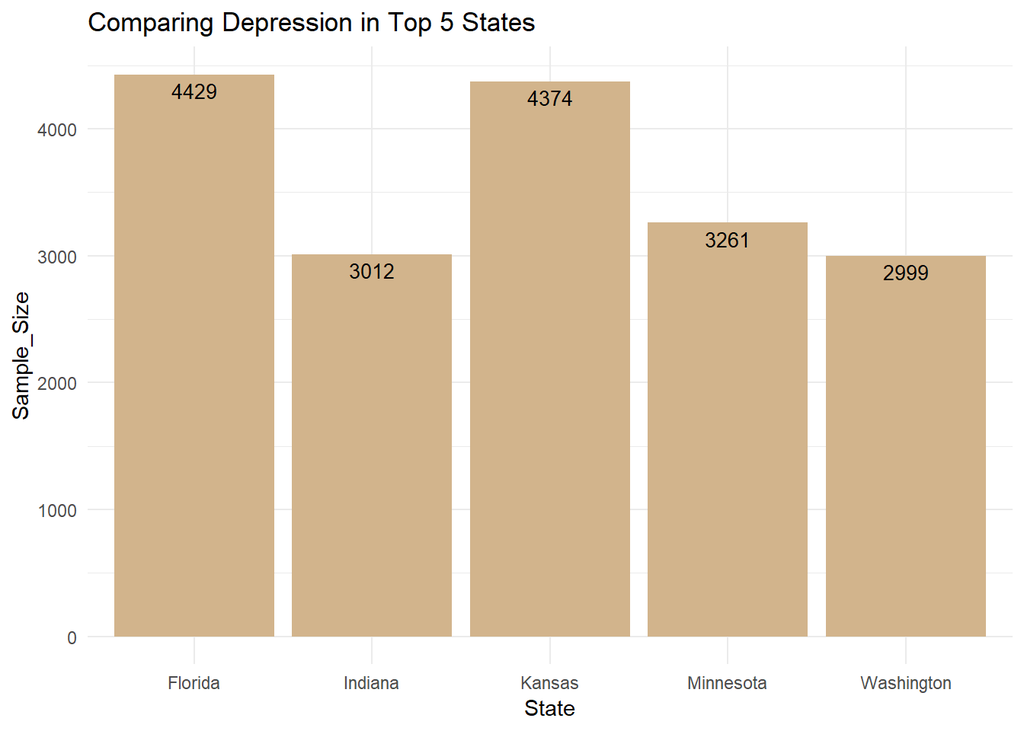

```r
# top 5 states with binge drinking 2017
top_n(targ_dep7, n=5, Sample_Size) %>%
  ggplot(., aes(x=Locationdesc, y=Sample_Size))+ labs(title = "Comparing Depression in Top 5 States", x = "State") +
  geom_bar(stat = 'identity', fill = "tan")+ geom_text(aes(label=Sample_Size), vjust=1.5, color="black", size = 3.5)+ theme_minimal()
```

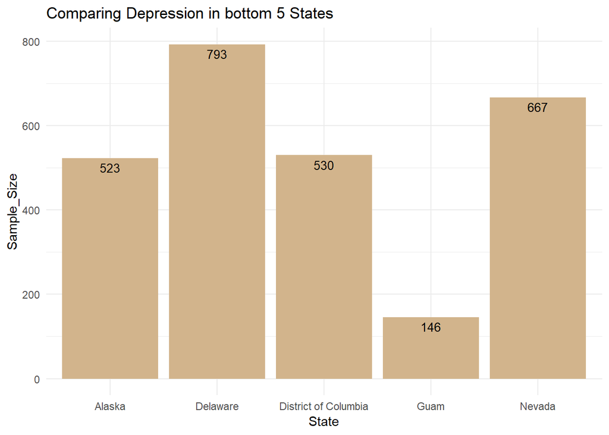

```r
# plotting the bottom 5 states with binge drinking for 2017
top_n(targ_dep7, n=-5, Sample_Size) %>%
  ggplot(., aes(x=Locationdesc, y=Sample_Size))+ labs(title = "Comparing Depression in bottom 5 States", x = "State") +
  geom_bar(stat = 'identity', fill = "tan")+ geom_text(aes(label=Sample_Size), vjust=1.5, color="black", size = 3.5)+ theme_minimal()
```

In 2017 Florida had most depression cases whiile Guam had the least.

**2011 cardiovascular disease data**

```r
# getting cardiovascular data 2011
targ_card <- filter(targ_b, Year == "2011", Response == "Yes", Topic == "Cardiovascular Disease")
View(targ_card)
```

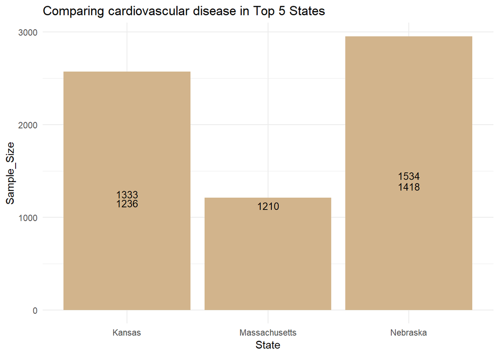

```r
# top 5 states with cardiovascular 2011
top_n(targ_card, n=5, Sample_Size) %>%
  ggplot(., aes(x=Locationdesc, y=Sample_Size))+ labs(title = "Comparing cardiovascular disease in Top 5 States", x = "State") +
  geom_bar(stat = 'identity', fill = "tan")+ geom_text(aes(label=Sample_Size), vjust=1.5, color="black", size = 3.5)+ theme_minimal()
```

**getting bottom 5 states cardiovascluar 2011**

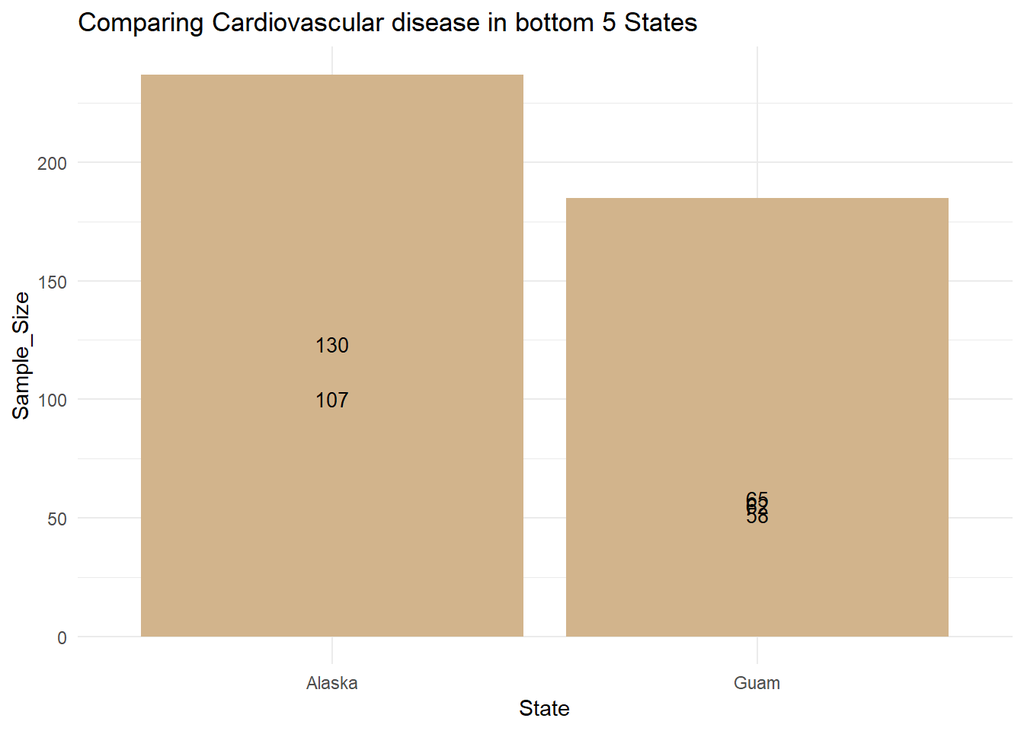

```r
# plotting the bottom 5 states with cardiovascular for 2011
top_n(targ_card, n=-5, Sample_Size) %>%
  ggplot(., aes(x=Locationdesc, y=Sample_Size))+ labs(title = "Comparing Cardiovascular disease in bottom 5 States", x = "State") +
  geom_bar(stat = 'identity', fill = "tan")+ geom_text(aes(label=Sample_Size), vjust=1.5, color="black", size = 3.5)+ theme_minimal()
```

**2012 cardiovascular disease data**

```r
# getting cardiovascular data 2012
targ_card2 <- filter(targ_b, Year == "2012", Response == "Yes", Topic == "Cardiovascular Disease")
View(targ_card2)
```

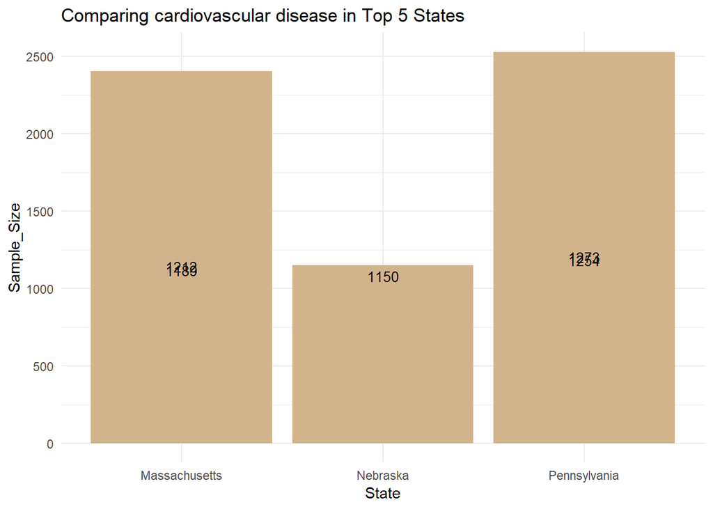

```r
# top 5 states with cardiovascular 2012
top_n(targ_card2, n=5, Sample_Size) %>%
  ggplot(., aes(x=Locationdesc, y=Sample_Size))+ labs(title = "Comparing cardiovascular disease in Top 5 States", x = "State") +
  geom_bar(stat = 'identity', fill = "tan")+ geom_text(aes(label=Sample_Size), vjust=1.5, color="black", size = 3.5)+ theme_minimal()
```

**getting bottom 5 states cardiovascluar 2012**

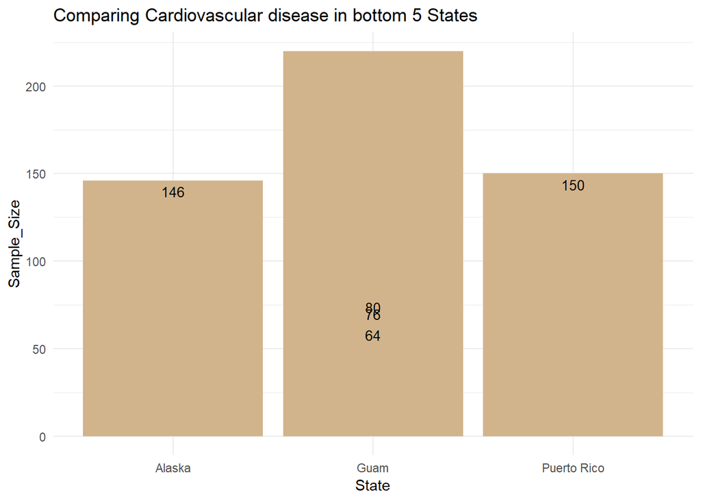

```r
# plotting the bottom 5 states with cardiovascular for 2012
top_n(targ_card2, n=-5, Sample_Size) %>%
  ggplot(., aes(x=Locationdesc, y=Sample_Size))+ labs(title = "Comparing Cardiovascular disease in bottom 5 States", x = "State") +
  geom_bar(stat = 'identity', fill = "tan")+ geom_text(aes(label=Sample_Size), vjust=1.5, color="black", size = 3.5)+ theme_minimal()
```

**2013 cardiovascular disease data**

```r
# getting cardiovascular data 2013
targ_card3 <- filter(targ_b, Year == "2013", Response == "Yes", Topic == "Cardiovascular Disease")
View(targ_card3)
```

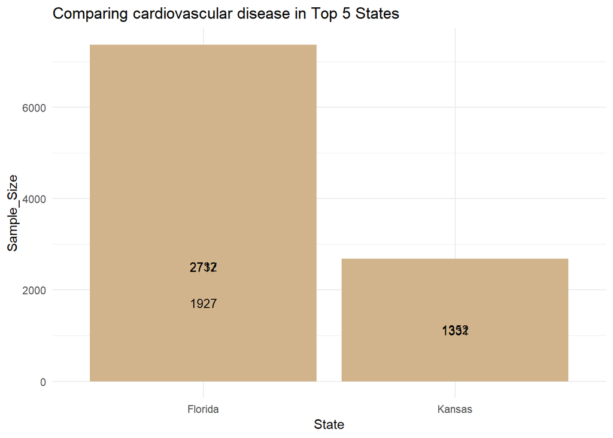

```r
# top 5 states with cardiovascular 2013
top_n(targ_card3, n=5, Sample_Size) %>%
  ggplot(., aes(x=Locationdesc, y=Sample_Size))+ labs(title = "Comparing cardiovascular disease in Top 5 States", x = "State") +
  geom_bar(stat = 'identity', fill = "tan")+ geom_text(aes(label=Sample_Size), vjust=1.5, color="black", size = 3.5)+ theme_minimal()
```

**getting bottom 5 states cardiovascluar 2013**

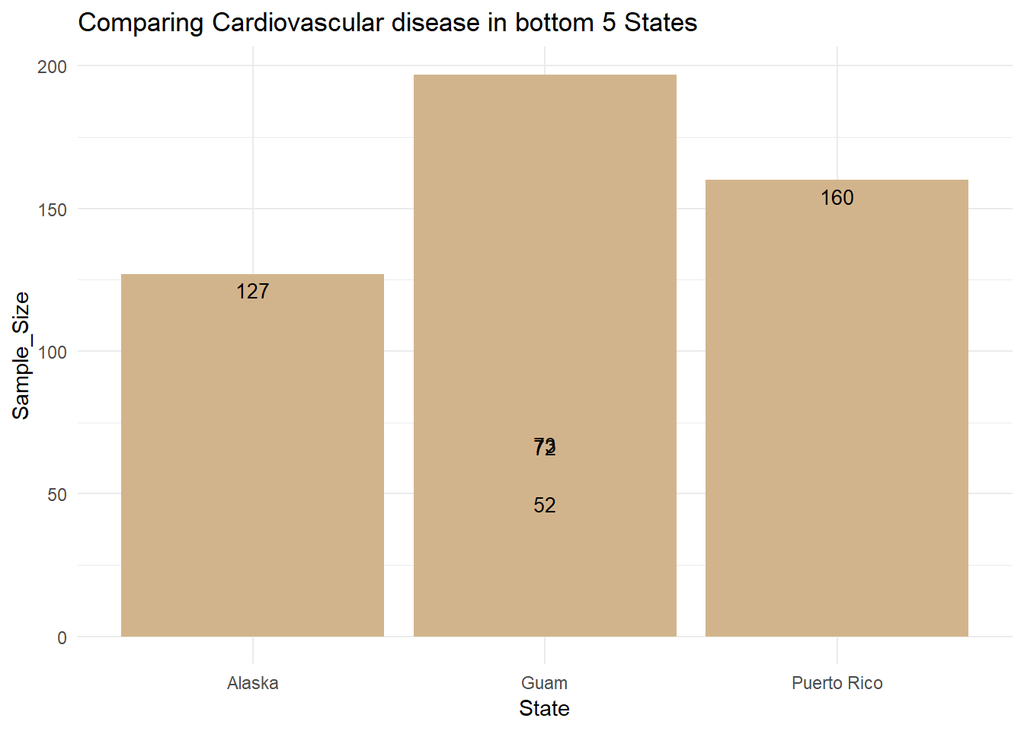

```r
# plotting the bottom 5 states with cardiovascular for 2013
top_n(targ_card3, n=-5, Sample_Size) %>%
  ggplot(., aes(x=Locationdesc, y=Sample_Size))+ labs(title = "Comparing Cardiovascular disease in bottom 5 States", x = "State") +
  geom_bar(stat = 'identity', fill = "tan")+ geom_text(aes(label=Sample_Size), vjust=1.5, color="black", size = 3.5)+ theme_minimal()
```

**2014 cardiovascular disease data**

```r
# getting cardiovascular data 2014
targ_card4 <- filter(targ_b, Year == "2014", Response == "Yes", Topic == "Cardiovascular Disease")
View(targ_card4)
```

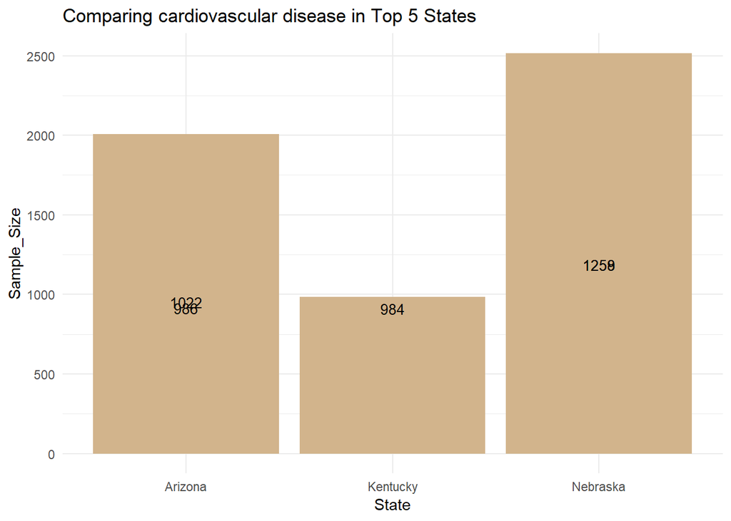

```r
# top 5 states with cardiovascular 2014
top_n(targ_card4, n=5, Sample_Size) %>%
  ggplot(., aes(x=Locationdesc, y=Sample_Size))+ labs(title = "Comparing cardiovascular disease in Top 5 States", x = "State") +
  geom_bar(stat = 'identity', fill = "tan")+ geom_text(aes(label=Sample_Size), vjust=1.5, color="black", size = 3.5)+ theme_minimal()
```

**getting bottom 5 states cardiovascluar 2014**

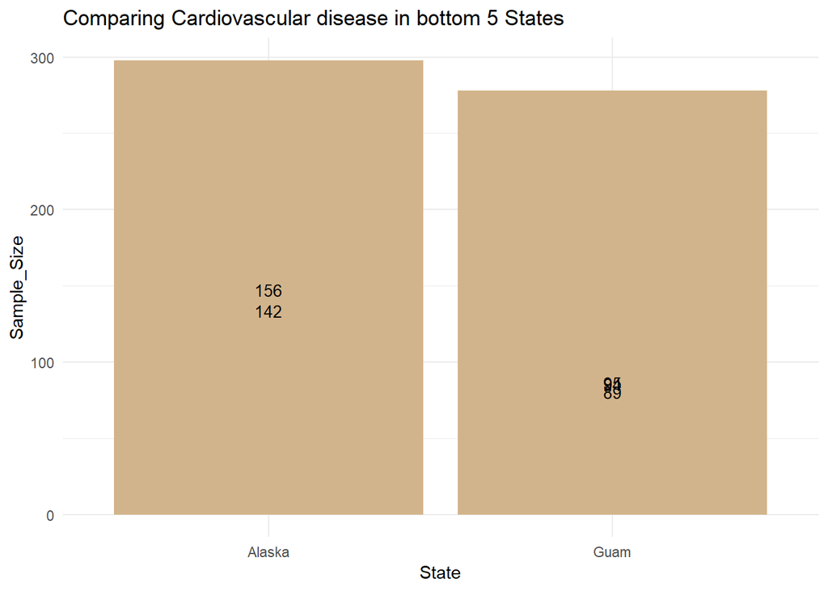

```r
# plotting the bottom 5 states with cardiovascular for 2014
top_n(targ_card4, n=-5, Sample_Size) %>%
  ggplot(., aes(x=Locationdesc, y=Sample_Size))+ labs(title = "Comparing Cardiovascular disease in bottom 5 States", x = "State") +
  geom_bar(stat = 'identity', fill = "tan")+ geom_text(aes(label=Sample_Size), vjust=1.5, color="black", size = 3.5)+ theme_minimal()
```

**2015 cardiovascular disease data**

```r
# getting cardiovascular data 2015
targ_card5 <- filter(targ_b, Year == "2015", Response == "Yes", Topic == "Cardiovascular Disease")
View(targ_card5)
```

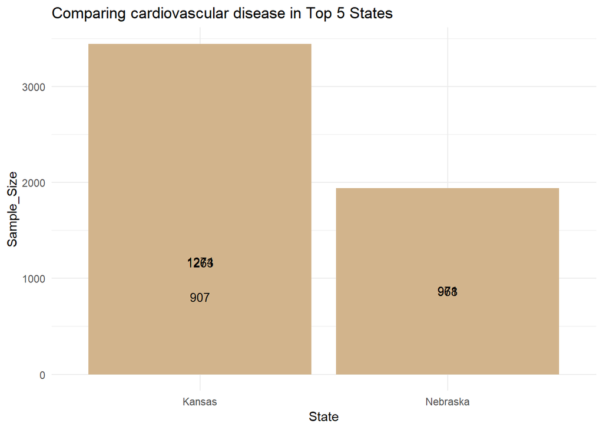

```r
# top 5 states with cardiovascular 2015
top_n(targ_card5, n=5, Sample_Size) %>%
  ggplot(., aes(x=Locationdesc, y=Sample_Size))+ labs(title = "Comparing cardiovascular disease in Top 5 States", x = "State") +
  geom_bar(stat = 'identity', fill = "tan")+ geom_text(aes(label=Sample_Size), vjust=1.5, color="black", size = 3.5)+ theme_minimal()
```

**getting bottom 5 states cardiovascluar 2015**

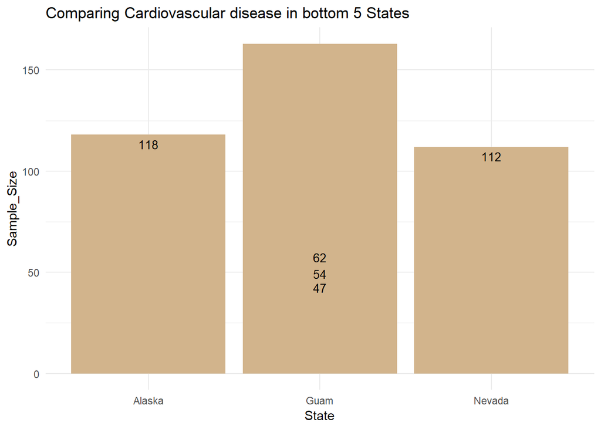

```r
# plotting the bottom 5 states with cardiovascular for 2015
top_n(targ_card5, n=-5, Sample_Size) %>%
  ggplot(., aes(x=Locationdesc, y=Sample_Size))+ labs(title = "Comparing Cardiovascular disease in bottom 5 States", x = "State") +
  geom_bar(stat = 'identity', fill = "tan")+ geom_text(aes(label=Sample_Size), vjust=1.5, color="black", size = 3.5)+ theme_minimal()
```

**2016 cardiovascular disease data**

```r
# getting cardiovascular data 2016
targ_card6 <- filter(targ_b, Year == "2016", Response == "Yes", Topic == "Cardiovascular Disease")
View(targ_card6)
```

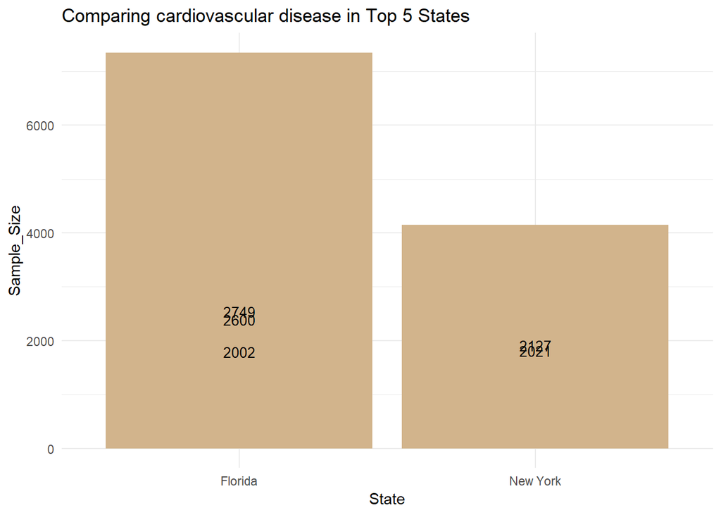

```r
# top 5 states with cardiovascular 2016
top_n(targ_card6, n=5, Sample_Size) %>%
  ggplot(., aes(x=Locationdesc, y=Sample_Size))+ labs(title = "Comparing cardiovascular disease in Top 5 States", x = "State") +
  geom_bar(stat = 'identity', fill = "tan")+ geom_text(aes(label=Sample_Size), vjust=1.5, color="black", size = 3.5)+ theme_minimal()
```

**getting bottom 5 states cardiovascluar 2016**

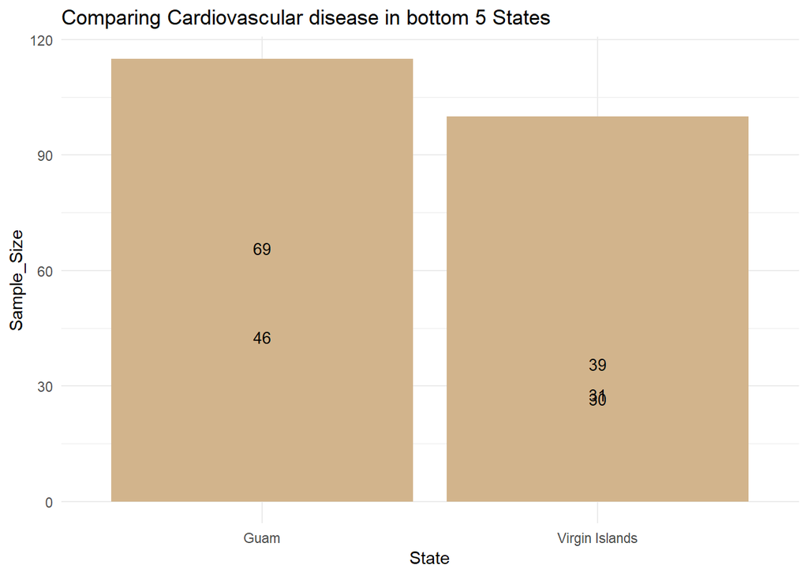

```r
# plotting the bottom 5 states with cardiovascular for 2016
top_n(targ_card6, n=-5, Sample_Size) %>%
  ggplot(., aes(x=Locationdesc, y=Sample_Size))+ labs(title = "Comparing Cardiovascular disease in bottom 5 States", x = "State") +
  geom_bar(stat = 'identity', fill = "tan")+ geom_text(aes(label=Sample_Size), vjust=1.5, color="black", size = 3.5)+ theme_minimal()
```

**2017 cardiovascular disease data**

```r
# getting cardiovascular data 2017
targ_card7 <- filter(targ_b, Year == "2017", Response == "Yes", Topic == "Cardiovascular Disease")
View(targ_card7)
```

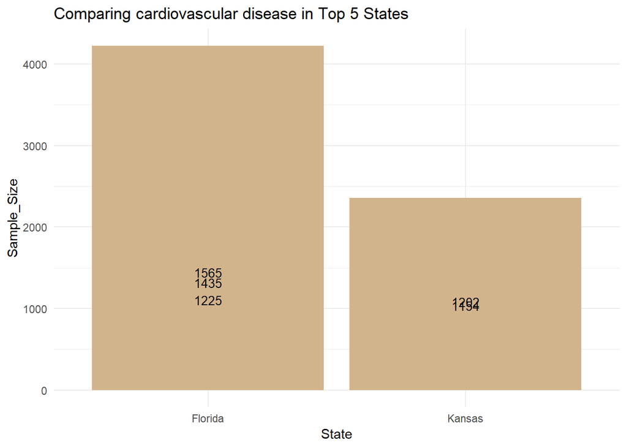

```r
# top 5 states with cardiovascular 2017
top_n(targ_card7, n=5, Sample_Size) %>%
  ggplot(., aes(x=Locationdesc, y=Sample_Size))+ labs(title = "Comparing cardiovascular disease in Top 5 States", x = "State") +
  geom_bar(stat = 'identity', fill = "tan")+ geom_text(aes(label=Sample_Size), vjust=1.5, color="black", size = 3.5)+ theme_minimal()
```

**getting bottom 5 states cardiovascluar 2017**

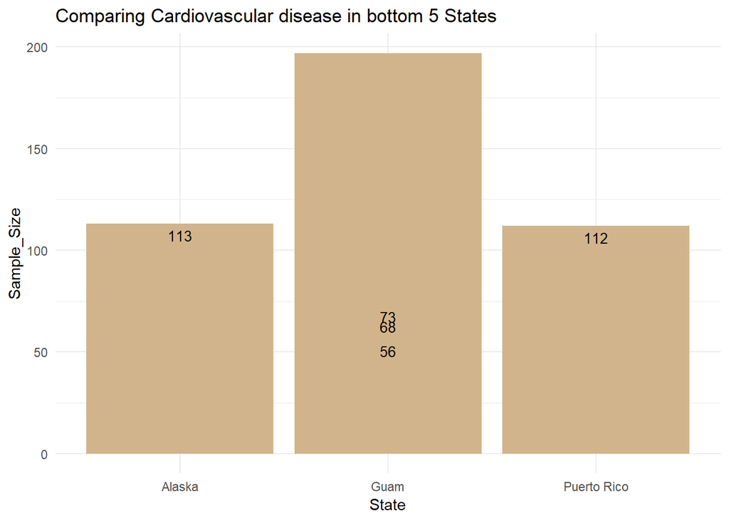

```r
# plotting the bottom 5 states with cardiovascular for 2017
top_n(targ_card7, n=-5, Sample_Size) %>%
  ggplot(., aes(x=Locationdesc, y=Sample_Size))+ labs(title = "Comparing Cardiovascular disease in bottom 5 States", x = "State") +
  geom_bar(stat = 'identity', fill = "tan")+ geom_text(aes(label=Sample_Size), vjust=1.5, color="black", size = 3.5)+ theme_minimal()
```

In Summary, the analysis was a success, the visual showed the occurence of various conditions in various state. A general assessment showed that Kansas, Florida and Massachusetts were leading in most categories in most year, while Guam and Virgin Islands were the last most of the time. I believe the sample size used in this study was not to conclusivel say that it is a clear depiction of the entire country. I also felt like since the sample size was calcalted in actual numbers the results wasn’t fair because some states have bigger popolation than others. A good example for this case would be Guam which is a small territory of the USa. It appeared in the bottom for most of the conditions because, it has a small population, hence, few people are being observed with the various conditions therefore making them appear to be safer of the covered medical conditions.